[figure not shown]

# Samsung Internal SSD Reviews prediction

Rating predictions using reviews written by users can be a useful problem statement in E-commerce domain and can be used for recommending similar products that may interest users. The dataset in this problem statement comprises reviews pertaining to Samsung Internal SSD product specifically SAMSUNG 850 EVO 2.5" 250GB SATA III 3D NAND Internal Solid State Drive (SSD) MZ-75E250B/AM from the NewEgg Store website. We will build a Natural Language processing model using Glove embeddings which is trained on reviews given by customers that have used the product and try to predict ratings given a new rating.

### Objective:

Given the reviews provided by customers, can you train a model that accurately predicts the corresponding rating of a review?

### Data Dictionary

- review_title : The Title for the customer review
- overall_review: The whole customer review details
- pros: The customer opinion about the good things in this product
- cons: The customer opinion about the bad things in this product
- ownership_pariod: How long the customer owned this product
- date: When the review was written
- rating_stars: The product rating from 1 to 5
- year: In which year the review was written
- month: In which month the review was written
- day: In which day the review was written

## Table of Content

1. Import Libraries
2. Setting options
3. Read Data
4. Data Analysis and Preparation
5. Model Building
6. Conclusion and Interpretation
7. Food for thought

## 1. Import Libraries

Let us start by mounting the drive

```python
from google.colab import drive
drive.mount('/content/drive')
```

Let us check for the version of installed tensorflow.

```python
# used to supress display of warnings
import warnings

# os is used to provide a way of using operating system dependent functionality
# We use it for setting working folder
import os

# Pandas is used for data manipulation and analysis
import pandas as pd

# Numpy is used for large, multi-dimensional arrays and matrices, along with mathematical operators on these arrays
import numpy as np

# Matplotlib is a data visualization library for 2D plots of arrays, built on NumPy arrays
# and designed to work with the broader SciPy stack
import matplotlib.pyplot as plt
%matplotlib inline
from matplotlib import pyplot

# Seaborn is based on matplotlib, which aids in drawing attractive and informative statistical graphics.
import seaborn as sns
import tensorflow
print(tensorflow.__version__)
```

```
2.5.0
```

## 2. Setting Options

```python
# suppress display of warnings
warnings.filterwarnings('ignore')

# display all dataframe columns
pd.options.display.max_columns = None

# to set the limit to 3 decimals
pd.options.display.float_format = '{:.7f}'.format

# display all dataframe rows
pd.options.display.max_rows = None
```

## 3. Read Data

### Read the dataset and check top 5 rows

```python
import cv2
import os
```

```python
from pandas import read_csv, Grouper, DataFrame, concat
```

```python
path = "/content/drive/MyDrive/Sequence model NLP/ssd_reviews.csv"
df = pd.read_csv(path)
```

```python
df.head(5)
```

|  | Unnamed: 0 | review_title | overall_review | pros | cons | ownership_pariod | date | rating_stars | year | month | day |
| --- | --- | --- | --- | --- | --- | --- | --- | --- | --- | --- | --- |
| 0 | 0 | solid | buy it you will not regret this purchase | reliable fast silent cool running drive highly... | NaN | years | 2019-12-05 12:58:58 | 5 | 2019 | 12 | 5 |
| 1 | 1 | nice drive for price even cheaper by todays costs | good drive price | been running almost constantly since when i pu... | NaN | years | 2019-11-01 08:25:45 | 5 | 2019 | 11 | 1 |
| 2 | 2 | perfect | used this drive as my boot drive and only data... | good value decently fast good longevity | none so far | years | 2019-10-27 17:05:49 | 5 | 2019 | 10 | 27 |
| 3 | 3 | very snappy | os boots quicker os menus pop up quicker gamin... | noticeable improvement in os performance over ... | samsung magician software causes some games to... | years | 2019-10-24 18:29:43 | 5 | 2019 | 10 | 24 |
| 4 | 4 | worth the hype | this was the sdd that everyone said to get and... | NaN | NaN | years | 2019-09-11 19:21:03 | 5 | 2019 | 9 | 11 |

```python
df.shape
```

```
(2227, 11)
```

### Check info of the dataset and write your findings

```python
df.info()
```

```
<class 'pandas.core.frame.DataFrame'>
RangeIndex: 2227 entries, 0 to 2226
Data columns (total 11 columns):
 #   Column            Non-Null Count  Dtype
---  ------            --------------  -----
 0   Unnamed: 0        2227 non-null   int64
 1   review_title      2131 non-null   object
 2   overall_review    1448 non-null   object
 3   pros              2205 non-null   object
 4   cons              2216 non-null   object
 5   ownership_pariod  2159 non-null   object
 6   date              2227 non-null   object
 7   rating_stars      2227 non-null   int64
 8   year              2227 non-null   int64
 9   month             2227 non-null   int64
 10  day               2227 non-null   int64
dtypes: int64(5), object(6)
memory usage: 191.5+ KB
```

we have 2227 Data points and 11 Featutes

we do have some missing values in the dataset

we have Data and day, month, year is a redundanr feature

## 4. Data Analysis and Preparation

### 4.1 Checking missing values

#### Check for missing values (along with the percentage of null values)

```python
df.isna().sum()
```

```
Unnamed: 0            0
review_title         96
overall_review      779
pros                 22
cons                 11
ownership_pariod     68
date                  0
rating_stars          0
year                  0
month                 0
day                   0
dtype: int64
```

```python
df.isna().sum()/ len(df) * 100
```

```
Unnamed: 0          0.0000000
review_title        4.3107319
overall_review     34.9797934
pros                0.9878761
cons                0.4939380
ownership_pariod    3.0534351
date                0.0000000
rating_stars        0.0000000
year                0.0000000
month               0.0000000
day                 0.0000000
dtype: float64
```

### 4.2 Analyzing the target column (Rating_stars)

#### Check the value counts of 'rating_stars' and write your comments

```python
df['rating_stars'].value_counts()
```

```
5    1756
4     181
1     153
3      77
2      60
Name: rating_stars, dtype: int64
```

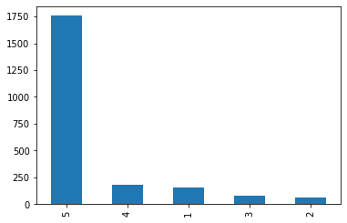

```python
df['rating_stars'].value_counts().plot(kind = 'bar')
```

### 4.3 Let's analyze other features like year, month, and day etc.

#### Check value counts of 'year' and write your observations., Comment on the range of years, frequency of ratings in each year.

```python
df['year'].value_counts()
```

```
2015    1006
2016     605
2017     370
2018     187
2019      46
2014      13
Name: year, dtype: int64
```

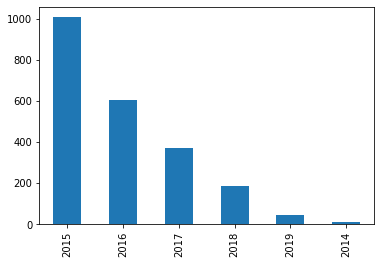

```python
df['year'].value_counts().plot(kind = 'bar')
```

#### Check mean rating for each year and write your findings

```python
df.groupby('year')['rating_stars'].mean()
```

```
year
2014   4.9230769
2015   4.4582505
2016   4.5900826
2017   4.5108108
2018   4.3475936
2019   4.3478261
Name: rating_stars, dtype: float64
```

#### Check value counts of 'month' and write your observations. Comment on the frequency of ratings and discuss if the rating count and mean rating is higher/low on certain months.

```python
df['month'].value_counts()
```

```
12    278
2     239
3     234
1     221
4     205
11    191
5     158
9     157
7     144
10    141
6     140
8     119
Name: month, dtype: int64
```

```python
df.groupby('month')['rating_stars'].mean().sort_values(ascending = False)
```

```
month
7    4.7638889
1    4.6425339
3    4.6111111
6    4.5571429
9    4.5414013
8    4.4789916
11   4.4607330
5    4.4493671
4    4.4195122
2    4.4058577
12   4.3597122
10   4.3049645
Name: rating_stars, dtype: float64
```

### 4.4 Combine text features

#### Drop all the numerical features ['Unnamed: 0','date', 'year', 'month', 'day', 'ownership_pariod'] and ['rating_stars']

```python
Numeric_cols = ['Unnamed: 0','date', 'year', 'month', 'day', 'ownership_pariod','rating_stars']
```

```python
text_data = df.drop(Numeric_cols, axis=1)
```

```python
text_data.head()
```

|  | review_title | overall_review | pros | cons |
| --- | --- | --- | --- | --- |
| 0 | solid | buy it you will not regret this purchase | reliable fast silent cool running drive highly... | NaN |
| 1 | nice drive for price even cheaper by todays costs | good drive price | been running almost constantly since when i pu... | NaN |
| 2 | perfect | used this drive as my boot drive and only data... | good value decently fast good longevity | none so far |
| 3 | very snappy | os boots quicker os menus pop up quicker gamin... | noticeable improvement in os performance over ... | samsung magician software causes some games to... |
| 4 | worth the hype | this was the sdd that everyone said to get and... | NaN | NaN |

#### Replace null values (NaN) with blanks

```python
text_data.isna().sum()
```

```
review_title       96
overall_review    779
pros               22
cons               11
dtype: int64
```

```python
text_data.fillna(" ", inplace = True)
```

```python
text_data.head()
```

|  | review_title | overall_review | pros | cons |
| --- | --- | --- | --- | --- |
| 0 | solid | buy it you will not regret this purchase | reliable fast silent cool running drive highly... |  |
| 1 | nice drive for price even cheaper by todays costs | good drive price | been running almost constantly since when i pu... |  |
| 2 | perfect | used this drive as my boot drive and only data... | good value decently fast good longevity | none so far |
| 3 | very snappy | os boots quicker os menus pop up quicker gamin... | noticeable improvement in os performance over ... | samsung magician software causes some games to... |
| 4 | worth the hype | this was the sdd that everyone said to get and... |  |  |

#### Join all text items in a row that have a space in between and Add a new column (with the newly created combined reviews) to the dataframe.

```python
text_data['combined_review'] = text_data[['review_title','overall_review','pros','cons']].apply(lambda x: ' '.join(x), axis=1)
```

```python
text_data.head()
```

|  | review_title | overall_review | pros | cons | combined_review |
| --- | --- | --- | --- | --- | --- |
| 0 | solid | buy it you will not regret this purchase | reliable fast silent cool running drive highly... |  | solid buy it you will not regret this purchase... |
| 1 | nice drive for price even cheaper by todays costs | good drive price | been running almost constantly since when i pu... |  | nice drive for price even cheaper by todays co... |
| 2 | perfect | used this drive as my boot drive and only data... | good value decently fast good longevity | none so far | perfect used this drive as my boot drive and o... |
| 3 | very snappy | os boots quicker os menus pop up quicker gamin... | noticeable improvement in os performance over ... | samsung magician software causes some games to... | very snappy os boots quicker os menus pop up q... |
| 4 | worth the hype | this was the sdd that everyone said to get and... |  |  | worth the hype this was the sdd that everyone ... |

```python
df1 = pd.DataFrame()
df1['combined_review']=text_data['combined_review']
df1['ratings'] = df['rating_stars']
df1.head()
```

|  | combined_review | ratings |
| --- | --- | --- |
| 0 | solid buy it you will not regret this purchase... | 5 |
| 1 | nice drive for price even cheaper by todays co... | 5 |
| 2 | perfect used this drive as my boot drive and o... | 5 |
| 3 | very snappy os boots quicker os menus pop up q... | 5 |
| 4 | worth the hype this was the sdd that everyone ... | 5 |

#### Check if there are any null values and drop NaN values if any

```python
df1.isna().sum()
```

```
combined_review    0
ratings            0
dtype: int64
```

#### Calculate the length of each review and add it to the dataframe

```python
df1['combined_review'].str.len()
```

```
0        105
1        226
2        308
3        250
4        138
5         75
6        106
7        120
8        853
9       1625
10       215
11       100
12        54
13       484
14        35
```

[output cut: 2213 more lines]

```python
df1['combined_review'][0]
```

```
'solid buy it you will not regret this purchase reliable fast silent cool running drive highly recommend  '
```

```python
df1['len'] = df1['combined_review'].apply(lambda x: len(x.split(" ")))
```

#### Check summary stats of the length column

```python
df1['len'].describe()
```

```
count   2227.0000000
mean      85.2752582
std       87.3063671
min        6.0000000
25%       31.0000000
50%       60.0000000
75%      109.0000000
max     1615.0000000
Name: len, dtype: float64
```

### 4.5 Analyzing and preparing the text data

#### Set the max length of each review to 25 since it results in faster training (however, you are free to change this)

#### Set max_features to 10000 and embedding size to 50

```python
max_features = 10000
maxlen = 25
embedding_size = 50
```

#### Tokenize the cobined text data. You can use the Tokenizer from tensorflow.keras.preprocessing.text. Check the number of samples post tokenization.

```python
from tensorflow.keras.preprocessing.text import Tokenizer

tokenizer = Tokenizer(num_words = max_features)
tokenizer.fit_on_texts(df1['combined_review'])

X = tokenizer.texts_to_sequences(df1['combined_review'])

print("Number of Samples" , len(X))
print(X[0])
```

```
Number of Samples 2227
[232, 93, 6, 19, 54, 22, 829, 10, 248, 162, 16, 830, 550, 145, 7, 264, 126]
```

```python
print(X)
```

[output not shown]

#### Pad the above tokenized reviews data save it as independent features. Use max_len for the same.

```python
from tensorflow.keras.preprocessing.sequence import pad_sequences

X_pad=pad_sequences(X, maxlen=maxlen)
print(X_pad[0])
```

```
[  0   0   0   0   0   0   0   0 232  93   6  19  54  22 829  10 248 162
  16 830 550 145   7 264 126]
```

#### Check the shape of X (padded tokenized review data) and y (rating_stars) data.

```python
X_pad.shape
```

```
(2227, 25)
```

```python
y = np.array(df1['ratings'])
y.shape
```

```
(2227,)
```

#### Check the total number of words in the dictionary (of tekenizer)

```python
num_words = len(tokenizer.word_index) + 1
print(num_words)
```

```
8839
```

### 4.6 Compute the glove embeddings. Use the provided txt file for the same.

```python
X_pad
```

```
array([[   0,    0,    0, ...,    7,  264,  126],
       [1541,  209,   77, ...,   14,  612,  931],
       [  21,   99,  472, ...,   31,   27,   87],
       ...,
       [   1,    8,   12, ...,   31,   27,   87],
       [ 247,   34,   20, ...,   14,    1,  612],
       [   5,  294,   13, ...,   10,  248,   31]], dtype=int32)
```

#### Read the glove embeddings from the file provided titled ‘glove.6B.50d.txt’. And save it to a dictotionary having word and corresponding embedding vector.

```python
Embedding_file = "/content/drive/MyDrive/Sequence model NLP/glove.6B.50d.txt"
embeddings = {}
count = 1

for o in open(Embedding_file):

  word = o.split(" ")[0]
  embd = o.split(" ")[1:]

  embeddings[word] = np.array(embd)
```

```python
len(embeddings)
```

```
400000
```

#### Create a weight matrix for words in the training docs

```python
embedding_matrix = np.zeros((num_words, 50))

for word, i in tokenizer.word_index.items():
  embedding_vector = embeddings.get(word)
  if embedding_vector is not None:
    embedding_matrix[i] = embedding_vector
```

```python
embedding_matrix.shape
```

```
(8839, 50)
```

```python
embedding_matrix[1]
```

```
array([ 4.1800e-01,  2.4968e-01, -4.1242e-01,  1.2170e-01,  3.4527e-01,
       -4.4457e-02, -4.9688e-01, -1.7862e-01, -6.6023e-04, -6.5660e-01,
        2.7843e-01, -1.4767e-01, -5.5677e-01,  1.4658e-01, -9.5095e-03,
        1.1658e-02,  1.0204e-01, -1.2792e-01, -8.4430e-01, -1.2181e-01,
       -1.6801e-02, -3.3279e-01, -1.5520e-01, -2.3131e-01, -1.9181e-01,
       -1.8823e+00, -7.6746e-01,  9.9051e-02, -4.2125e-01, -1.9526e-01,
        4.0071e+00, -1.8594e-01, -5.2287e-01, -3.1681e-01,  5.9213e-04,
        7.4449e-03,  1.7778e-01, -1.5897e-01,  1.2041e-02, -5.4223e-02,
       -2.9871e-01, -1.5749e-01, -3.4758e-01, -4.5637e-02, -4.4251e-01,
        1.8785e-01,  2.7849e-03, -1.8411e-01, -1.1514e-01, -7.8581e-01])
```

#### Check length of the embedding

```python
embedding_matrix.shape
```

```
(8839, 50)
```

### 4.7 Target Feature:- One hot encode the target variable (rating_stars)

```python
y
```

```
array([5, 5, 5, ..., 5, 5, 5])
```

```python
from tensorflow.keras.utils import to_categorical
y_enc = to_categorical(y)
y_enc
```

```
array([[0., 0., 0., 0., 0., 1.],
       [0., 0., 0., 0., 0., 1.],
       [0., 0., 0., 0., 0., 1.],
       ...,
       [0., 0., 0., 0., 0., 1.],
       [0., 0., 0., 0., 0., 1.],
       [0., 0., 0., 0., 0., 1.]], dtype=float32)
```

### 4.8 Split the data into Train & Test sets

```python
from sklearn.model_selection import train_test_split
Xtrain,Xtest,Ytrain,Ytest=train_test_split(X_pad,y_enc,test_size=0.3)
```

## 5. Model building

### 5.1 Construct a neural network architecture using embedding and LSTM layers for building the rating prediction model.

- Use the num_words, embedding_size from the above tokenizer and embeddings respectively
- Use weights from the above embedding matrix
- Use input length as the maxlen
- Add LSTM layers

```python
from tensorflow.keras.models import Sequential
from tensorflow.keras.layers import Dense, Embedding, LSTM, Dropout , Flatten

model = Sequential()
## Embedding layer
model.add(Embedding(num_words , embedding_size , weights = [embedding_matrix] , input_length = maxlen))
## LSTM layer
model.add(LSTM(128))
##Flatten
model.add(Flatten())
## Dense layer 1
model.add(Dense(128, activation = 'relu'))
## Dense layer 2
model.add(Dense(64, activation = 'relu'))
model.add(Dropout(0.2))
## Output layer
model.add(Dense(6, activation = 'softmax'))
```

### 5.2 Compile the model using appropriate loss, optimizer, and accuracy metric

```python
 model.compile(loss = 'categorical_crossentropy' , optimizer = 'adam' , metrics = 'accuracy')
```

```python
model.summary()
```

```
Model: "sequential_1"
_________________________________________________________________
Layer (type)                 Output Shape              Param #
=================================================================
embedding_1 (Embedding)      (None, 25, 50)            441950
_________________________________________________________________
lstm_1 (LSTM)                (None, 128)               91648
_________________________________________________________________
flatten_1 (Flatten)          (None, 128)               0
_________________________________________________________________
dense_3 (Dense)              (None, 128)               16512
_________________________________________________________________
dense_4 (Dense)              (None, 64)                8256
_________________________________________________________________
dropout_1 (Dropout)          (None, 64)                0
_________________________________________________________________
dense_5 (Dense)              (None, 6)                 390
=================================================================
Total params: 558,756
Trainable params: 558,756
Non-trainable params: 0
_________________________________________________________________
```

### 5.3 Fit the model

```python
history = model.fit(Xtrain, Ytrain, epochs = 20, validation_data = (Xtest, Ytest))
```

### 5.4 Predict ratings for test data and check accuracy and confusion matrix

```python
prediction = model.predict(Xtest)
prediction = np.argmax(prediction , axis =1)
prediction
```

```
array([5, 5, 5, 4, 3, 5, 5, 5, 1, 5, 5, 1, 5, 4, 4, 5, 5, 5, 5, 4, 5, 5,
       5, 5, 5, 4, 5, 4, 5, 4, 5, 5, 5, 5, 5, 5, 5, 5, 5, 5, 1, 5, 5, 4,
       5, 5, 3, 5, 4, 5, 5, 5, 5, 5, 5, 5, 5, 4, 5, 4, 3, 4, 1, 5, 5, 5,
       5, 1, 5, 2, 1, 4, 5, 5, 2, 4, 5, 5, 5, 5, 4, 5, 5, 5, 5, 5, 5, 5,
       5, 5, 5, 5, 5, 5, 4, 5, 5, 5, 5, 1, 5, 5, 5, 5, 5, 5, 1, 5, 5, 5,
       5, 5, 5, 5, 5, 5, 5, 5, 5, 5, 5, 5, 5, 5, 5, 5, 5, 5, 4, 5, 5, 5,
       5, 1, 5, 5, 5, 5, 5, 5, 4, 5, 5, 5, 5, 5, 5, 5, 5, 5, 5, 5, 5, 4,
       2, 5, 1, 5, 5, 5, 5, 1, 5, 4, 1, 5, 5, 1, 5, 5, 5, 5, 1, 5, 5, 5,
       5, 5, 5, 5, 5, 5, 5, 5, 1, 5, 5, 5, 4, 4, 4, 5, 5, 5, 4, 5, 5, 5,
       1, 5, 5, 5, 5, 5, 4, 5, 5, 5, 5, 5, 1, 5, 5, 5, 5, 5, 5, 5, 5, 5,
       5, 5, 5, 5, 5, 5, 5, 5, 4, 5, 5, 5, 5, 5, 5, 5, 5, 4, 5, 5, 5, 5,
       5, 5, 5, 5, 5, 5, 1, 5, 5, 5, 5, 5, 5, 5, 5, 5, 5, 5, 5, 4, 5, 1,
       5, 5, 5, 5, 5, 5, 5, 5, 5, 5, 5, 1, 5, 5, 5, 5, 5, 5, 5, 5, 5, 1,
       5, 5, 5, 5, 5, 5, 5, 5, 5, 5, 5, 5, 5, 5, 5, 5, 5, 5, 4, 5, 5, 5,
       5, 5, 5, 5, 5, 5, 5, 5, 5, 5, 5, 5, 5, 3, 5, 5, 5, 5, 1, 5, 5, 5,
```

[output cut: 16 more lines]

```python
Ytest
```

```
array([[0., 0., 0., 0., 0., 1.],
       [0., 0., 0., 0., 0., 1.],
       [0., 0., 0., 0., 0., 1.],
       ...,
       [0., 0., 0., 0., 0., 1.],
       [0., 0., 0., 0., 0., 1.],
       [0., 0., 0., 0., 0., 1.]], dtype=float32)
```

```python
Ytest_ = np.argmax(np.array(Ytest), axis = 1)
print(Ytest_)
```

```
[5 5 5 5 5 4 4 5 1 5 5 5 3 5 4 5 5 5 5 5 5 5 5 2 1 3 5 5 5 5 5 2 5 5 5 5 5
 5 5 5 5 5 5 5 4 5 3 5 4 5 5 5 4 5 5 5 5 5 5 5 4 1 2 5 5 5 5 1 5 5 5 5 5 5
 5 5 5 5 5 4 4 5 5 4 5 5 5 5 5 5 3 4 5 5 5 4 5 5 5 1 5 5 5 5 5 5 3 5 5 5 5
 5 5 5 5 5 1 5 5 5 5 5 5 5 5 5 5 5 5 5 4 5 5 1 1 5 5 5 5 5 5 5 5 5 5 4 5 5
 5 5 5 5 5 1 5 5 2 5 5 5 5 1 5 5 5 2 5 1 5 5 4 5 1 5 5 4 5 5 5 5 5 5 5 5 1
 5 5 5 5 5 4 5 5 5 5 2 5 5 1 5 5 5 5 5 5 5 5 5 5 5 1 5 5 5 5 5 5 5 5 4 5 5
 5 5 5 5 5 5 4 5 5 5 5 5 5 5 4 5 5 5 5 5 5 5 5 5 5 5 1 5 5 5 5 5 5 5 5 5 5
 5 5 1 5 1 5 5 2 5 5 5 5 5 5 5 5 3 5 5 5 5 5 5 5 5 5 1 5 5 3 5 5 5 5 5 5 5
 5 5 5 5 5 5 5 5 4 5 4 5 5 5 5 4 5 5 5 5 5 5 5 5 5 5 5 5 5 2 5 5 5 5 5 4 3
 4 4 1 4 2 2 5 4 5 5 5 5 5 5 3 5 1 5 5 5 5 5 5 5 5 5 5 5 5 5 5 5 5 5 4 5 5
 5 5 5 1 5 5 5 4 1 5 1 5 5 5 5 5 5 5 5 1 5 3 5 5 5 5 2 5 5 5 5 5 5 5 5 5 5
 2 5 5 5 5 4 5 1 5 5 5 1 5 5 5 5 3 3 5 5 5 5 5 5 5 5 5 5 1 5 3 5 5 5 5 5 5
 5 5 5 5 5 5 5 5 5 5 5 5 5 1 5 5 5 5 5 2 5 4 5 3 5 5 4 5 5 1 5 5 5 5 5 5 1
 2 5 2 5 1 5 5 5 5 5 5 5 5 5 5 5 5 3 5 5 5 5 5 4 5 5 5 4 4 5 5 5 5 5 5 4 5
 5 5 5 5 5 5 5 4 5 5 5 5 5 5 5 5 5 5 5 5 5 5 5 4 3 5 5 5 1 5 5 2 5 5 5 5 5
 5 5 5 5 5 5 5 5 5 4 5 5 4 5 3 5 5 5 1 5 5 5 5 5 5 5 5 2 5 5 4 5 5 5 4 4 5
 5 5 5 1 5 5 5 2 5 5 5 5 5 5 5 1 2 5 4 5 2 5 5 5 5 5 5 5 5 4 5 5 5 1 5 5 5
 5 1 5 3 5 5 5 5 5 5 3 5 5 5 5 1 2 5 5 3 5 5 2 5 5 5 5 5 5 1 5 4 5 1 4 5 5
 5 5 5]
```

```python
from sklearn.metrics import confusion_matrix, classification_report
```

```python
print(confusion_matrix (Ytest_ , prediction))
```

```
[[ 18   2   2   5  14]
 [  4   5   1   3   9]
 [  5   2   2   3   8]
 [  1   0   1  11  35]
 [ 10   6   3  39 480]]
```

```python
print(classification_report(Ytest_ , prediction))
```

```
              precision    recall  f1-score   support

           1       0.47      0.44      0.46        41
           2       0.33      0.23      0.27        22
           3       0.22      0.10      0.14        20
           4       0.18      0.23      0.20        48
           5       0.88      0.89      0.89       538

    accuracy                           0.77       669
   macro avg       0.42      0.38      0.39       669
weighted avg       0.77      0.77      0.77       669
```

### 5.5 Display plot of training and validation loss/accuracy wrt to epochs

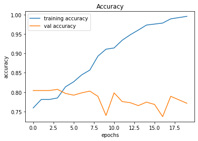

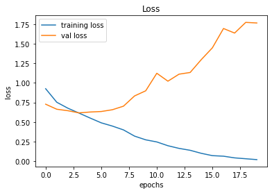

```python
#Display of the accuracy and the loss values
import matplotlib.pyplot as plt

plt.figure(0)
plt.plot(history.history['accuracy'], label='training accuracy')
plt.plot(history.history['val_accuracy'], label='val accuracy')
plt.title('Accuracy')
plt.xlabel('epochs')
plt.ylabel('accuracy')
plt.legend()

plt.figure(1)
plt.plot(history.history['loss'], label='training loss')
plt.plot(history.history['val_loss'], label='val loss')
plt.title('Loss')
plt.xlabel('epochs')
plt.ylabel('loss')
plt.legend()
```

## 6. Conclusion and Interpretation

```python
# Model is over fitting
```

## 7. Food for thought:

1.) Change activation function (try leaky_relu or tanh) and see if it helps in improving model performance with the dataset that is highly imbalanced

2.) Try with only the overall review feature and see if it leads to improvement in model performace

3.) Change the hyperparameters of the model and compare the results